# Survey Sampling Final Report

Group 6

2025-05-26

## **Q2_8. 您主要從哪裡學習理財知識？**

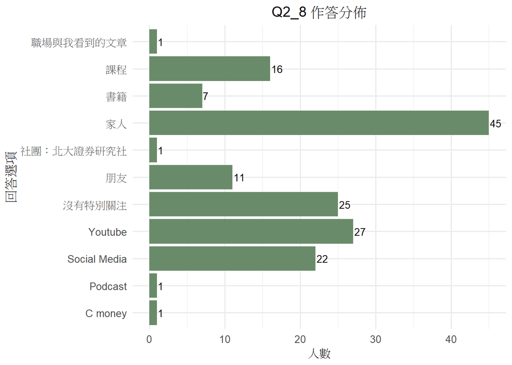

由長條圖分佈，有 28.7% (45人) 的學生透過「家人」習得理財相關知識，其次為「Youtube」與「Social Media」，分別為 17.2% (27人) 及 14% (22人)。此外也有 15.9% (25人) 表示沒有特別關注理財相關知識。

```r
# 建立新的變數 Q2_8_grouped，將少數類別合併為「其他」
dfnew$Q2_8_grouped <- dfnew$Q2_8
dfnew$Q2_8_grouped[dfnew$Q2_8 %in% c("職場與我看到的文章", "社團：北大證券研究社", "Podcast", "C money")] <- "其他"

# 檢查是否合併成功
table(dfnew$Q2_8_grouped)
```

```
##
## Social Media      Youtube 沒有特別關注         其他         朋友         家人
##           22           27           25            4           11           45
##         書籍         課程
##            7           16
```

為進行卡方檢定以探討不同資訊來源在學生間的分布是否具有統計差異，我們將 Q2_8 題目中出現人數較少的選項重新分類至「其他」類別，包含「職場與我看到的文章」、「社團: 北大證券研究社」、「Podcast」與「C money」，各 1 人。合併後的類別包含：「Social Media」、「Youtube」、「沒有特別關注」、「書籍」、「課程」、「朋友」、「家人」與「其他」，如表格所示。此分類方式有助於避免期望次數過低所造成的檢定偏誤，符合卡方檢定的適用前提，後續將以此分組進行列聯表與檢定分析。

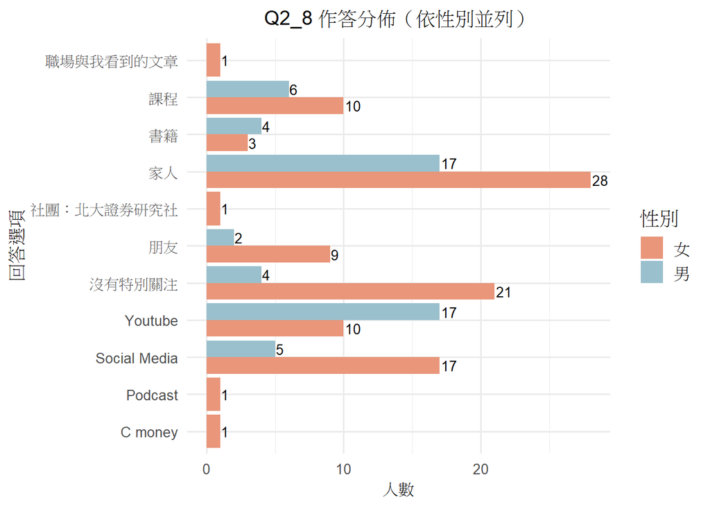

從圖中可以觀察到，男女學生在資訊來源的選擇上有明顯不同，例如女生較常透過「家人」、「Social Media」獲得理財知識，而男生則相對較常透過「Youtube」來獲取理財知識，且在表示「沒有特別特別關注」的分佈中，女生人數明顯高過男生。

```r
tbl1 <- table(dfnew$gender, dfnew$Q2_8_grouped)
chisq.test(tbl1)
```

```
##
##  Pearson's Chi-squared test
##
## data:  tbl1
## X-squared = 19.922, df = 7, p-value = 0.005741
```

根據卡方檢定結果（ 𝜒<sup>2</sup> = 19.922, df = 7, p = 0.0057），性別與理財學習來源之間在統計上具有顯著關聯，表示男女學生在獲取理財知識的管道上存在明顯差異。儘管部分類別的期望值仍略低，經過合併低頻選項後，檢定結果較為穩定，具參考價值。

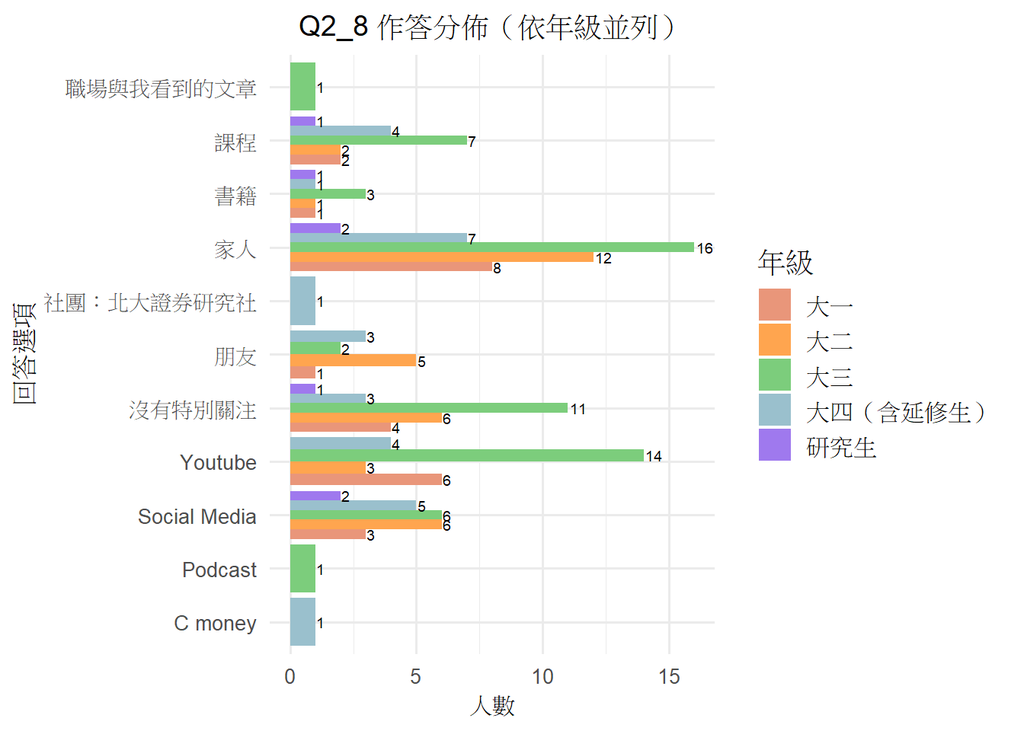

由圖可觀察，大三學生在多數資訊來源的選擇上占比較高，例如在「Youtube」、「家人」、「沒有特別關注」等類別中皆為人數最多的一群。而低年級學生則在資訊選擇上呈現較為分散的情形。

```r
tbl_grade <- table(dfnew$grade, dfnew$Q2_8_grouped)
chisq.test(tbl_grade)
```

```
##
##  Pearson's Chi-squared test
##
## data:  tbl_grade
## X-squared = 21.042, df = 28, p-value = 0.8236
```

根據卡方檢定結果（𝜒<sup>2</sup> = 21.042，df = 28，p = 0.8236），並未發現年級與理財學習來源之間具有統計上顯著關聯，表示不同年級學生在資訊來源的選擇上整體而言並無顯著差異。雖然各年級略有偏好，但並不足以構成統計上的差異。

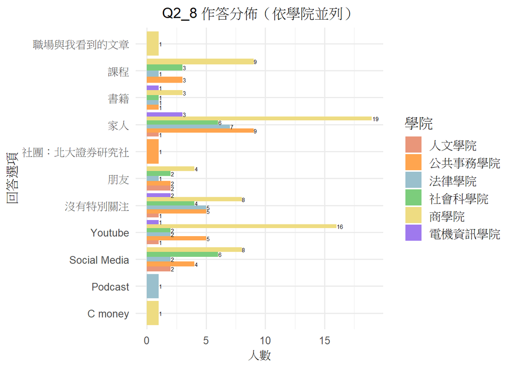

由圖顯示，不同學院學生在各類資訊來源的使用上略有差異，例如來自商學院的學生明顯偏好透過「家人」、「Youtube」與「課程」獲取理財相關知識；而法律學院與社會科學院的學生則呈現資訊來源分布較為分散的情況。

```r
tbl_college <- table(dfnew$college, dfnew$Q2_8_grouped)
chisq.test(tbl_college)
```

```
##
##  Pearson's Chi-squared test
##
## data:  tbl_college
## X-squared = 23.441, df = 35, p-value = 0.9319
```

根據卡方檢定結果（𝜒<sup>2</sup> = 23.441，df = 35，p = 0.9319），學院與資訊來源間的差異並不具統計顯著性，表示學生的資訊來源選擇在不同學院間並無顯著差異。雖然可觀察到商學院學生在部分選項中的人數相對較多，但整體而言，學院別對資訊來源的影響不明顯。

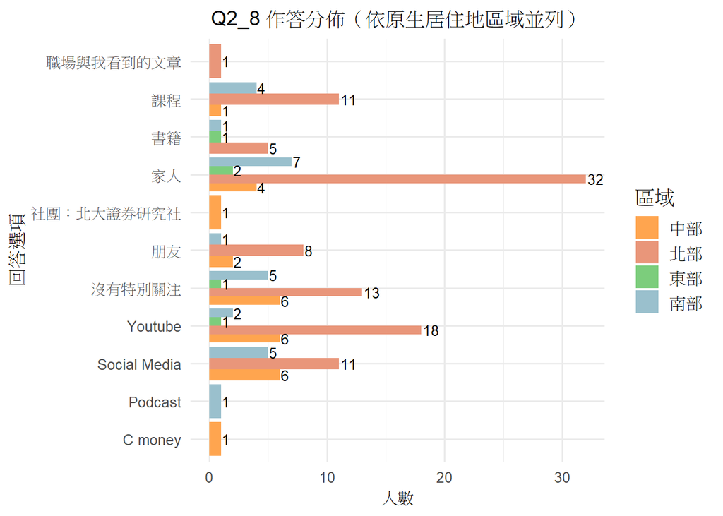

從圖表觀察可以看出，北部學生在大多數資訊來源的選項中皆占有較高比例，特別是在「家人」、「Youtube」與「沒有特別關注」三類上顯得尤為明顯。中部與南部學生在人數上相對較少，但其資訊來源分布則較為平均。

```r
tbl_region <- table(dfnew$region, dfnew$Q2_8_grouped)
chisq.test(tbl_region)
```

```
##
##  Pearson's Chi-squared test
##
## data:  tbl_region
## X-squared = 19.868, df = 21, p-value = 0.5297
```

根據卡方檢定結果（𝜒<sup>2</sup> = 19.868，df = 21，p = 0.5297），原生地區與理財資訊來源間並無統計上顯著的關聯，表示不同地區學生在資訊來源的選擇上整體趨勢類似。

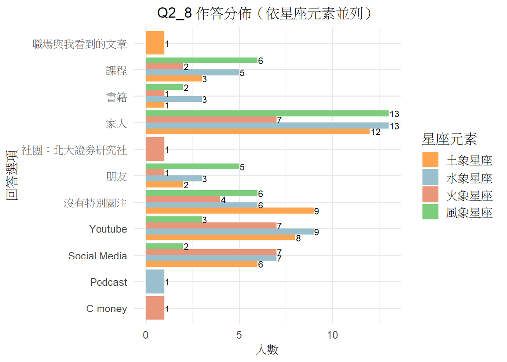

圖表中可見，各星座元素間學生在資訊來源選擇上的分布情形大致相似，尤以「家人」、「Youtube」、「Social Media」與「沒有特別關注」四類為主流選擇，在各星座元素間皆有一定人數。

```r
tbl_triplicity <- table(dfnew$triplicity, dfnew$Q2_8_grouped)
chisq.test(tbl_triplicity)
```

```
##
##  Pearson's Chi-squared test
##
## data:  tbl_triplicity
## X-squared = 17.47, df = 21, p-value = 0.6823
```

雖然部分差異略為明顯，但根據卡方檢定結果（𝜒<sup>2</sup> = 17.47，df = 21，p = 0.6823），並未顯示星座分類與理財資訊來源之間具有統計顯著關聯。

## **Q2_11. 我認同「投資風險越高，報酬越高」**

```r
# Q2_11 summary
summary(dfnew$Q2_11)
```

```
##    Min. 1st Qu.  Median    Mean 3rd Qu.    Max.
##   1.000   4.000   4.000   4.064   5.000   5.000
```

```r
# variance of Q2_11
q2_11_var <- var(dfnew$Q2_11, na.rm = TRUE)
q2_11_var
```

```
## [1] 0.8420709
```

```r
# standard deviation of Q2_11
sqrt(q2_11_var)
```

```
## [1] 0.9176442
```

平均作答為 4.06，標準差為 0.92，顯示整體對此題有較高程度的認同，且回答分布相對集中。四分位數分布為 Q1 = 4、Q2 = 4、Q3 = 5，代表有半數以上的受訪者選擇 4 分以上，整體偏向正向看法。最小值與最大值分別為 1 與 5，顯示雖有極端意見存在，但不影響整體傾向。

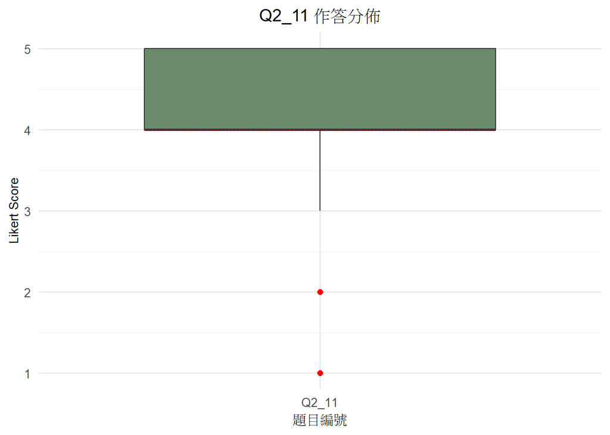

根據圖表，大部分受訪者的作答集中於 4 至 5 分之間，顯示對此題普遍抱持高度認同。中位數為 4，盒型上緣達到最大值 5，代表許多受訪者選擇最高分。圖中亦出現少數離群值（1 分與 2 分），但整體分布偏向正向，反映此題在受測群體中具高度共識。

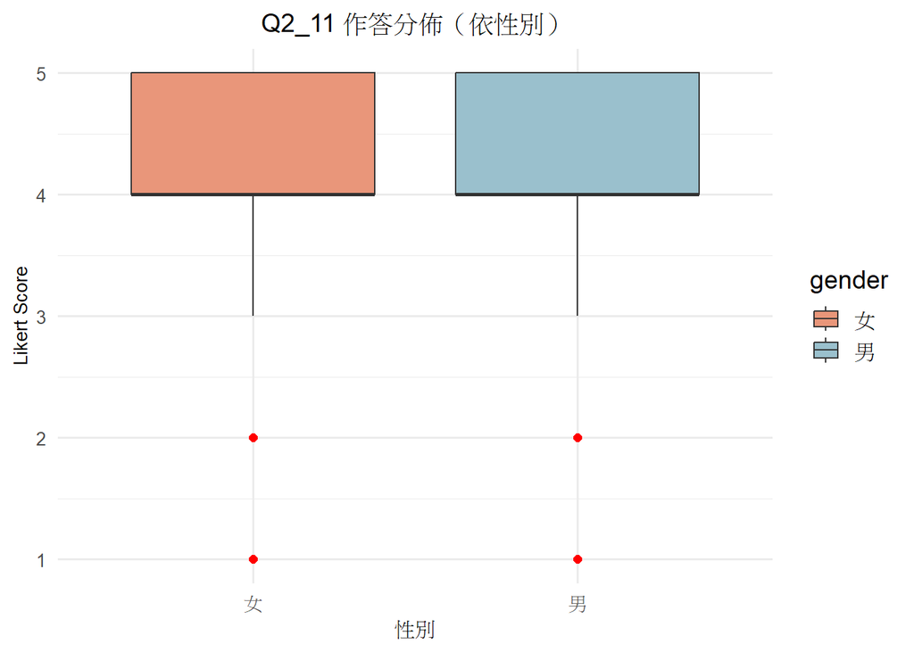

男女在作答分布趨近一致，兩者中位數皆為 4，四分位範圍落在 4 至 5，表示大多數受試者對此題均給予高度認同。僅少數離群值落於 1 至 2 分，顯示少部分受訪者持相對保留態度，整體而言性別在此題上差異不大。

```
## # A tibble: 2 × 9
##   gender  mean variance    sd   min    Q1    Q2    Q3   max
##   <chr>  <dbl>    <dbl> <dbl> <dbl> <dbl> <dbl> <dbl> <dbl>
## 1 女      4.04     0.83  0.91     1     4     4     5     5
## 2 男      4.11     0.88  0.94     1     4     4     5     5
```

```r
# t-test Q2_11 by gender
Q2_11_data <- df_long %>%
  filter(question == "Q2_11")

# 檢查樣本數（確認兩組性別都有資料）
table(Q2_11_data$gender)
```

```
##
##  女  男
## 102  55
```

```r
# 進行獨立樣本 t 檢定（Welch's t-test）
t.test(response ~ gender, data = Q2_11_data, var.equal = FALSE)
```

```
##
##  Welch Two Sample t-test
##
## data:  response by gender
## t = -0.45029, df = 108.14, p-value = 0.6534
## alternative hypothesis: true difference in means between group 女 and group 男 is not equal to 0
## 95 percent confidence interval:
##  -0.3774575  0.2377070
## sample estimates:
## mean in group 女 mean in group 男
##         4.039216         4.109091
```

女性與男性的平均作答分數相近。由 Two-Sample t-Test 分析結果後，p 值為 0.6534，大於 0.05，表示不同性別在此題的平均分數差異不具統計顯著性，顯示性別對此的回答影響不大。

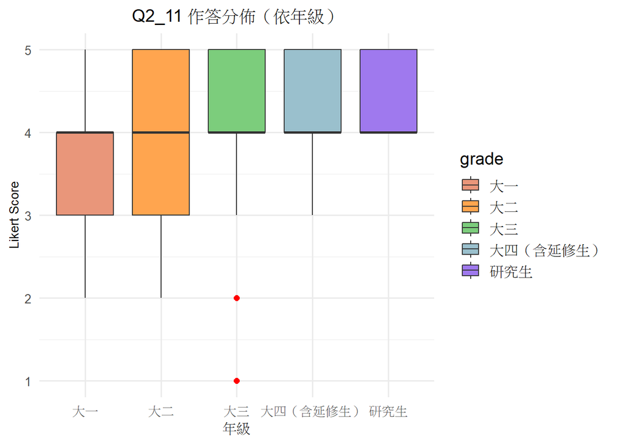

```
## # A tibble: 5 × 9
##   grade             mean variance    sd   min    Q1    Q2    Q3   max
##   <chr>            <dbl>    <dbl> <dbl> <dbl> <dbl> <dbl> <dbl> <dbl>
## 1 大一              3.88     0.78  0.88     2     3     4     4     5
## 2 大三              3.97     1.07  1.03     1     4     4     5     5
## 3 大二              4.06     0.88  0.94     2     3     4     5     5
## 4 大四（含延修生）  4.34     0.45  0.67     3     4     4     5     5
## 5 研究生            4.43     0.29  0.53     4     4     4     5     5
```

```r
# ANOVA Q2_11 by grade
Q2_11_data <- df_long %>%
  filter(question == "Q2_11")

anova_result <- aov(response ~ grade, data = Q2_11_data)
summary(anova_result)
```

```
##              Df Sum Sq Mean Sq F value Pr(>F)
## grade         4   4.64  1.1592    1.39   0.24
## Residuals   152 126.73  0.8337
```

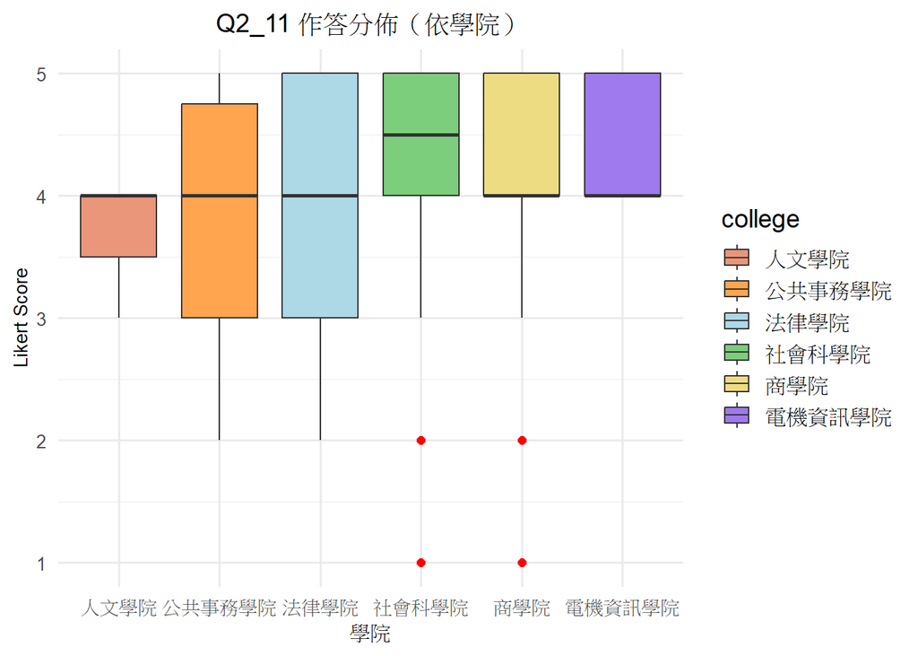

```
## # A tibble: 6 × 9
##   college       mean variance    sd   min    Q1    Q2    Q3   max
##   <chr>        <dbl>    <dbl> <dbl> <dbl> <dbl> <dbl> <dbl> <dbl>
## 1 人文學院      3.71     0.24  0.49     3   3.5   4    4        4
## 2 公共事務學院  3.93     0.69  0.83     2   3     4    4.75     5
## 3 商學院        4.14     0.83  0.91     1   4     4    5        5
## 4 法律學院      3.85     1.08  1.04     2   3     4    5        5
## 5 社會科學院    4.17     1.19  1.09     1   4     4.5  5        5
## 6 電機資訊學院  4.43     0.29  0.53     4   4     4    5        5
```

各學院平均得分介於 3.71 至 4.43 之間，整體差異不大。

```r
# ANOVA Q2_11 by college
Q2_11_data <- df_long %>%
  filter(question == "Q2_11")

anova_result <- aov(response ~ college, data = Q2_11_data)
summary(anova_result)
```

```
##              Df Sum Sq Mean Sq F value Pr(>F)
## college       5   3.92  0.7839   0.929  0.464
## Residuals   151 127.44  0.8440
```

由 ANOVA 分析結果， F 值為 0.929，p 值為 0.464，遠高於 0.05 顯著水準，表示不同學院在此題的平均作答分數差異不具有統計上的顯著性。因此，學生所屬學院對本題回應的影響並不明顯。

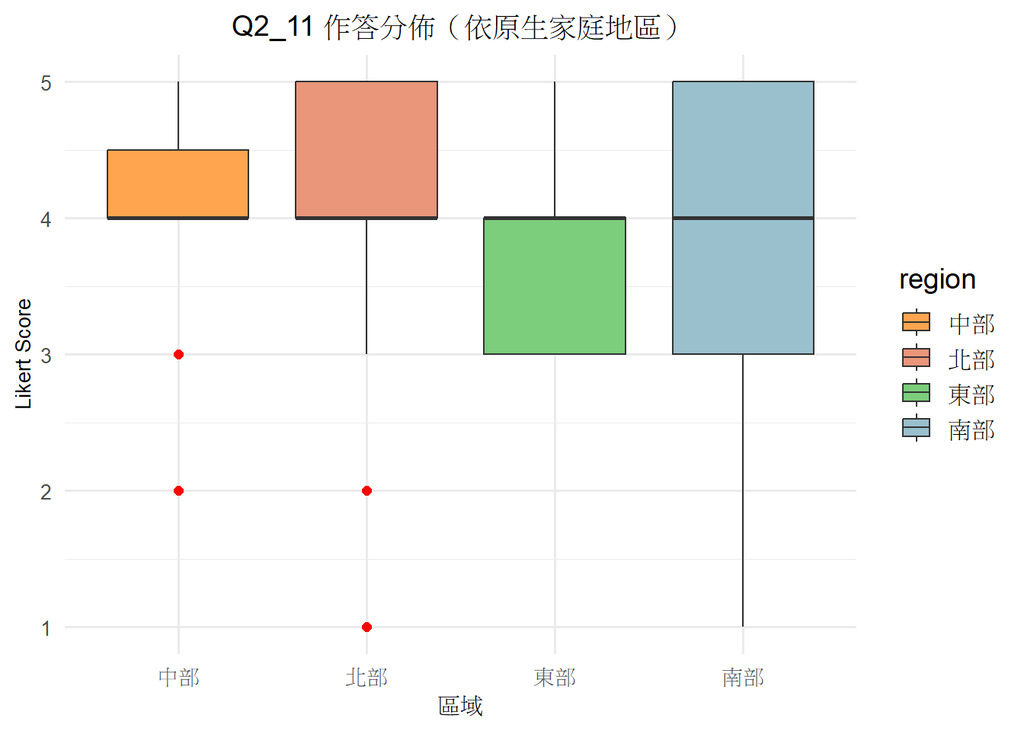

從 boxplot 圖可觀察到，不同地區的學生在此題的 Likert 分數分布略有差異，北部與中部學生的中位數與上四分位偏高，顯示他們較傾向認同該觀點；而來自東部的學生平均分數略低，可能對風險與報酬的連動關係持較保守或懷疑的看法。

```
## # A tibble: 4 × 9
##   region  mean variance    sd   min    Q1    Q2    Q3   max
##   <chr>  <dbl>    <dbl> <dbl> <dbl> <dbl> <dbl> <dbl> <dbl>
## 1 中部    4.04     0.65  0.81     2     4     4   4.5     5
## 2 北部    4.1      0.79  0.89     1     4     4   5       5
## 3 南部    4        1.36  1.17     1     3     4   5       5
## 4 東部    3.8      0.7   0.84     3     3     4   4       5
```

各地區平均得分介於 3.80（東部）至 4.10（北部）之間，整體變異不大。

```r
# ANOVA Q2_11 by region
Q2_11_data <- df_long %>%
  filter(question == "Q2_11")

anova_result <- aov(response ~ region, data = Q2_11_data)
summary(anova_result)
```

```
##              Df Sum Sq Mean Sq F value Pr(>F)
## region        3   0.61  0.2034   0.238   0.87
## Residuals   153 130.75  0.8546
```

根據 ANOVA 分析結果（F = 0.238，p = 0.870），原生地區對該題的回答並未產生統計上顯著的影響，表示不同地區學生對「高風險帶來高報酬」的看法整體趨於一致，無顯著認知差異。

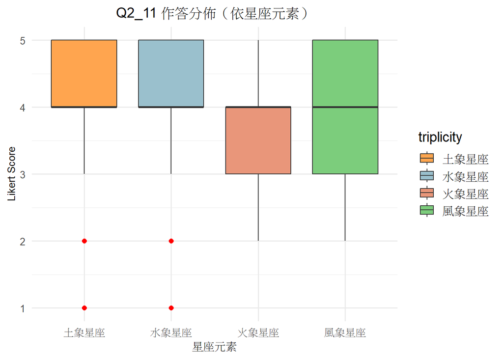

```
## # A tibble: 4 × 9
##   triplicity  mean variance    sd   min    Q1    Q2    Q3   max
##   <chr>      <dbl>    <dbl> <dbl> <dbl> <dbl> <dbl> <dbl> <dbl>
## 1 土象星座    4.26     0.78  0.89     1     4     4     5     5
## 2 水象星座    4.09     0.91  0.95     1     4     4     5     5
## 3 火象星座    3.87     0.72  0.85     2     3     4     4     5
## 4 風象星座    3.97     0.92  0.96     2     3     4     5     5
```

從 boxplot 圖可觀察，各星座元素在 Likert 分數上的分布略有不同，土象星座的平均分數最高（M = 4.26），代表此群體相對較認同風險與報酬呈正比的觀念；火象星座的平均最低（M = 3.87），可能相對持較保守或審慎態度。整體分布也顯示出部分異常值存在於水象與土象群體內。

```r
# ANOVA Q2_11 by triplicity
Q2_11_data <- df_long %>%
  filter(question == "Q2_11")

anova_result <- aov(response ~ triplicity, data = Q2_11_data)
summary(anova_result)
```

```
##              Df Sum Sq Mean Sq F value Pr(>F)
## triplicity    3   3.13  1.0425   1.244  0.296
## Residuals   153 128.24  0.8381
```

由 ANOVA 結果顯示，不同星座元素間在該題選項的回答上並未達到統計顯著差異（F = 1.244，p = 0.296），表示四象星座分類在此觀點的認同程度上整體趨勢相近，並無明顯的性格取向差異。

## **Q3_1. 您每月平均「非必要性開銷」金額為何？**

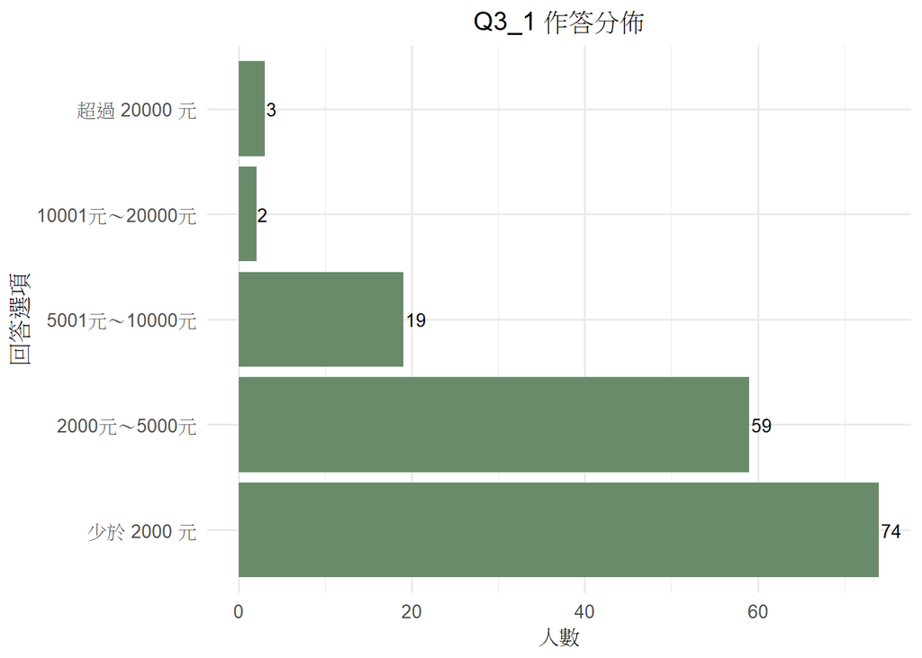

從圖中可見，多數學生每月在非必要消費上的支出集中於「少於 2000 元」（74 人）與「2000 元～5000 元」（59 人）兩個區間，合計佔大多數，顯示整體而言學生在非必要開銷方面較為節制。支出介於「5001 元～10000 元」者則為 19 人，僅有極少數學生表示支出超過 10000 元（共 5 人，其中 3 人為「超過 20000 元」）。此分布反映學生非必要性消費傾向偏低，可能受到生活費來源限制或理財觀念影響。

```r
dfnew$Q3_1_grouped <- as.numeric(dfnew$Q3_1)

dfnew$Q3_1_grouped[dfnew$Q3_1 %in% c("10001元～20000元", "超過 20000 元", "5001元～10000元")] <- "高支出"
dfnew$Q3_1_grouped[dfnew$Q3_1 == "2000元～5000元"] <- "中支出"
dfnew$Q3_1_grouped[dfnew$Q3_1 == "少於 2000 元"] <- "低支出"

dfnew$Q3_1_grouped <- factor(dfnew$Q3_1_grouped, levels = c("低支出", "中支出", "高支出"))

table(dfnew$Q3_1_grouped)
```

```
##
## 低支出 中支出 高支出
##     74     59     24
```

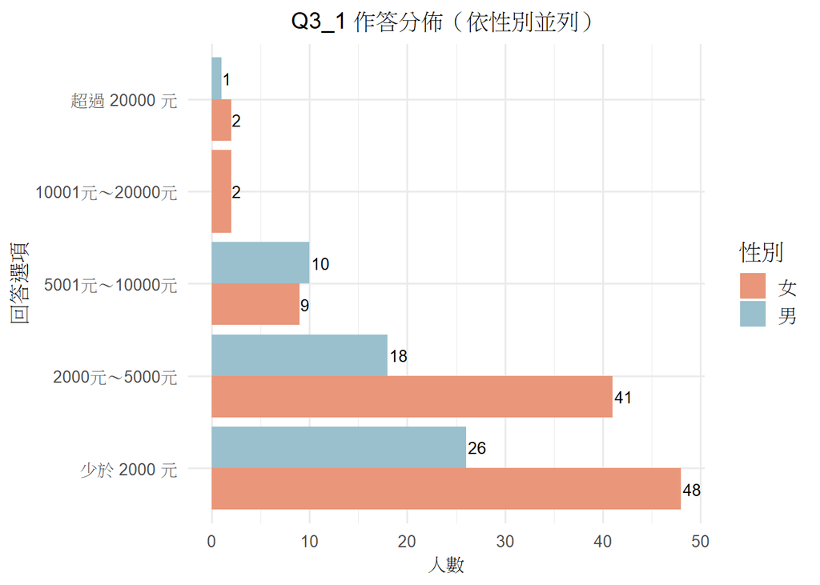

女生多集中於「少於 2000 元」（48 人）與「2000～5000 元」（41 人）兩個區間，顯示其整體支出偏低。男生亦同，多集中於「少於 2000 元」（26 人）與「2000～5000 元」（18 人）兩個區間。

```r
chisq.test(table(dfnew$gender, dfnew$Q3_1_grouped))
```

```
##
##  Pearson's Chi-squared test
##
## data:  table(dfnew$gender, dfnew$Q3_1_grouped)
## X-squared = 1.7611, df = 2, p-value = 0.4146
```

透過對性別做卡方檢定，卡方檢定結果為 𝜒<sup>2</sup> = 1.76，df = 2，p = 0.4146，性別與支出分類無顯著關聯，表示男女在非必要性支出金額上的分布並無明顯差異，個人消費偏好可能比性別影響更大。

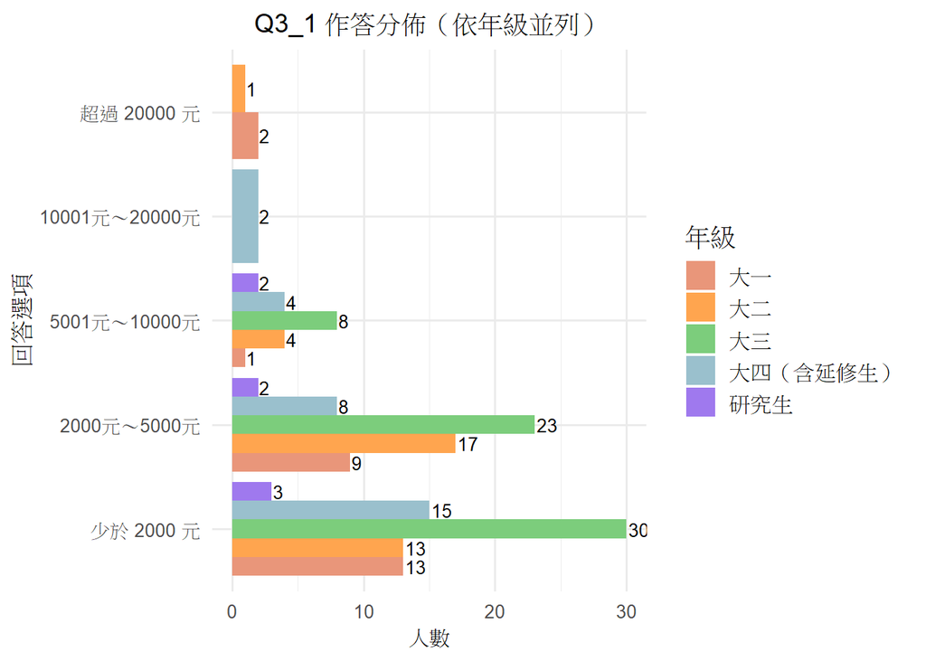

在「少於 2000 元」的選項中，大三學生人數最多（30 人），其後為大四（15 人）。「2000 元～5000 元」則以大三學生為主（23 人），其次為大二（17 人）與大一（9 人）。整體而言，各年級學生的非必要支出主要集中在「少於 2000 元」與「2000～5000 元」兩個區間，不同年級在其餘級距的分布差異較小。

```r
chisq.test(table(dfnew$grade, dfnew$Q3_1_grouped))
```

```
##
##  Pearson's Chi-squared test
##
## data:  table(dfnew$grade, dfnew$Q3_1_grouped)
## X-squared = 4.8916, df = 8, p-value = 0.7691
```

透過對年級做卡方檢定，檢定結果為 𝜒<sup>2</sup> = 4.89，df = 8，p = 0.7691，不同年級的學生在支出分類上的分布並無統計顯著差異，推論年級與非必要性消費金額之間無明確關聯。

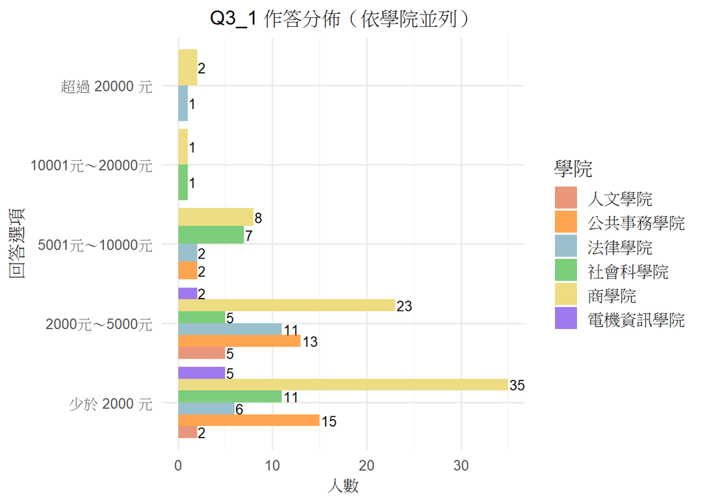

這張圖顯示不同學院學生在該題選項中每月非必要支出的分布情形。整體而言，多數學生的支出集中在「少於 2000 元」與「2000～5000 元」兩個區間，以商學院學生人數最多，在各級距中皆有相對較高的比例。其餘學院的學生則分布較為平均，高支出（超過 10000 元）者則整體偏少。

```r
chisq.test(table(dfnew$college, dfnew$Q3_1_grouped))
```

```
##
##  Pearson's Chi-squared test
##
## data:  table(dfnew$college, dfnew$Q3_1_grouped)
## X-squared = 17.902, df = 10, p-value = 0.05663
```

透過對不同學院做卡方檢定，檢定結果為 𝜒<sup>2</sup> = 17.90，df = 10，p = 0.0566，雖未達顯著水準(p < 0.05)，但結果接近顯著，表示不同學院學生間的支出模式可能存在差異。

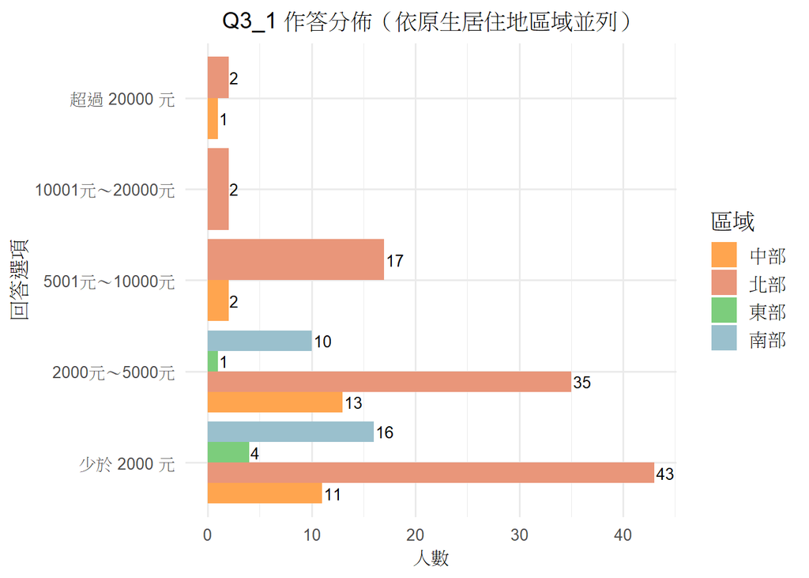

圖表呈現不同原生居住地區學生在該題題項中每月非必要支出金額的分布情況。北部學生占比最多，並在各個支出區間皆有分布，尤以「少於 2000 元」與「2000～5000 元」人數最多，分別為 43 人與 35 人。南部學生則以「少於 2000 元」（16 人）與「2000～5000 元」（10 人）為主，較少出現在高支出區間。中部與東部學生樣本數較少，主要集中於低支出範圍。整體而言，各地區學生多落在較低的支出區間，支出超過 10000 元者為少數。

```r
chisq.test(table(dfnew$region, dfnew$Q3_1_grouped))
```

```
##
##  Pearson's Chi-squared test
##
## data:  table(dfnew$region, dfnew$Q3_1_grouped)
## X-squared = 11.482, df = 6, p-value = 0.07456
```

透過對不同出生地做卡方檢定，檢定結果為 𝜒<sup>2</sup> = 11.48，df = 6，p = 0.0746，地區與非必要性支出分類間無顯著關聯（p > 0.05），但 p 值接近顯著，可推測地區文化或生活成本可能對消費行為產生影響。

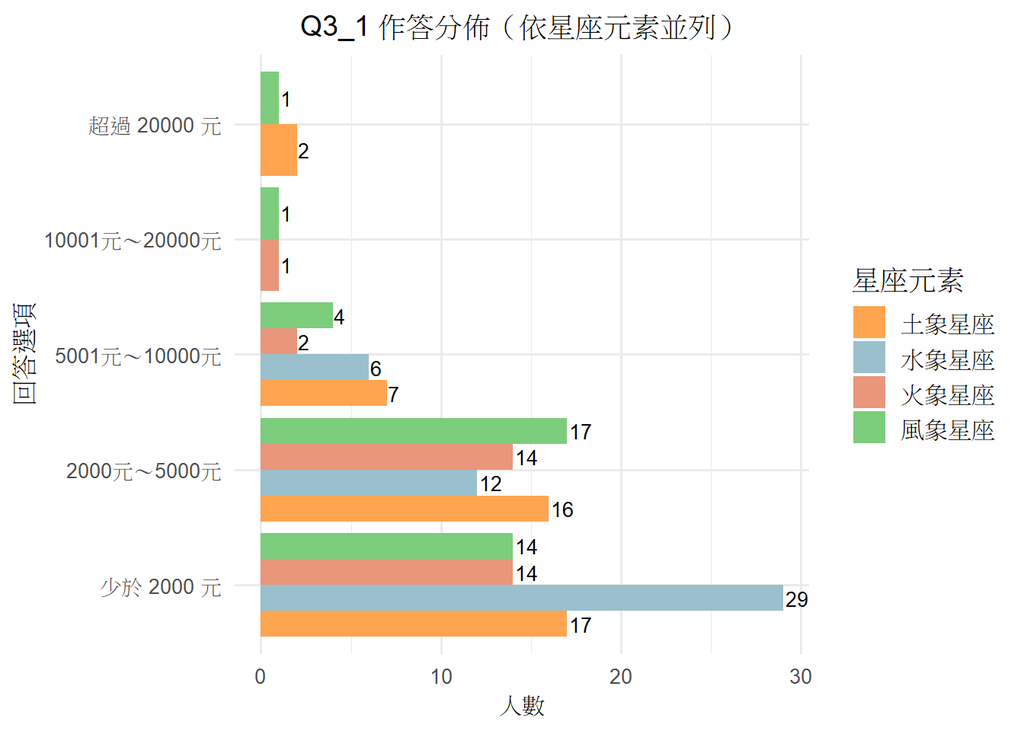

圖表顯示不同星座元素學生在該題選項中每月非必要支出金額的分布情形。各星座群體的支出主要集中於「少於 2000 元」與「2000～5000 元」，其中水象星座在低支出區間人數最多（29 人），風象星座在中支出區間（2000～5000 元）相對偏高（17 人）。在高支出區間（超過 5000 元），各群體分布較平均，整體而言，各星座元素在非必要支出上的差異不大，分布趨勢類似。

```r
chisq.test(table(dfnew$triplicity, dfnew$Q3_1_grouped))
```

```
##
##  Pearson's Chi-squared test
##
## data:  table(dfnew$triplicity, dfnew$Q3_1_grouped)
## X-squared = 8.0876, df = 6, p-value = 0.2318
```

透過對星座做卡方檢定，檢定結果為 𝜒<sup>2</sup> = 8.09，df = 6，p = 0.2318，星座與非必要性支出分類在統計上不顯著，推測人格特質對消費行為較無關聯。

## **Q3_3. 我經常出現衝動性消費的情況**

```r
# q3_3 original

summary(dfnew$Q3_3)
```

```
##    Min. 1st Qu.  Median    Mean 3rd Qu.    Max.
##   1.000   2.000   3.000   2.949   4.000   5.000
```

```r
#variance
diagonal_variance <- diag(var(dfnew$Q3_3))
diagonal_variance
```

```
##      [,1]
## [1,]    1
```

```r
#standard deviation
sqrt(diagonal_variance)
```

```
##      [,1]
## [1,]    1
```

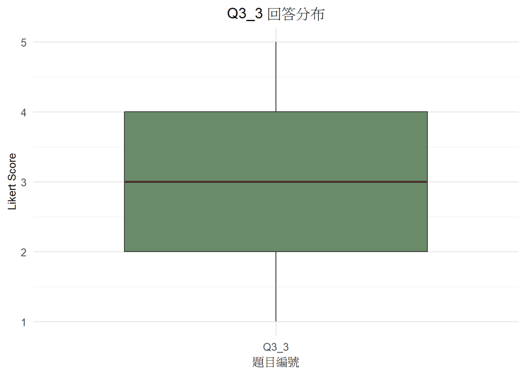

從盒鬍圖可見，大部分學生的回答集中在 2 到 4 之間，無明顯極端值，顯示多數學生對於自身是否經常衝動性消費的認知落在中間或偏向否定，而非強烈認同。

整體而言，填答者對衝動性消費的自我評價呈現中間偏保守傾向，但也保留一定的變異，可能與個人習慣或情境有關。

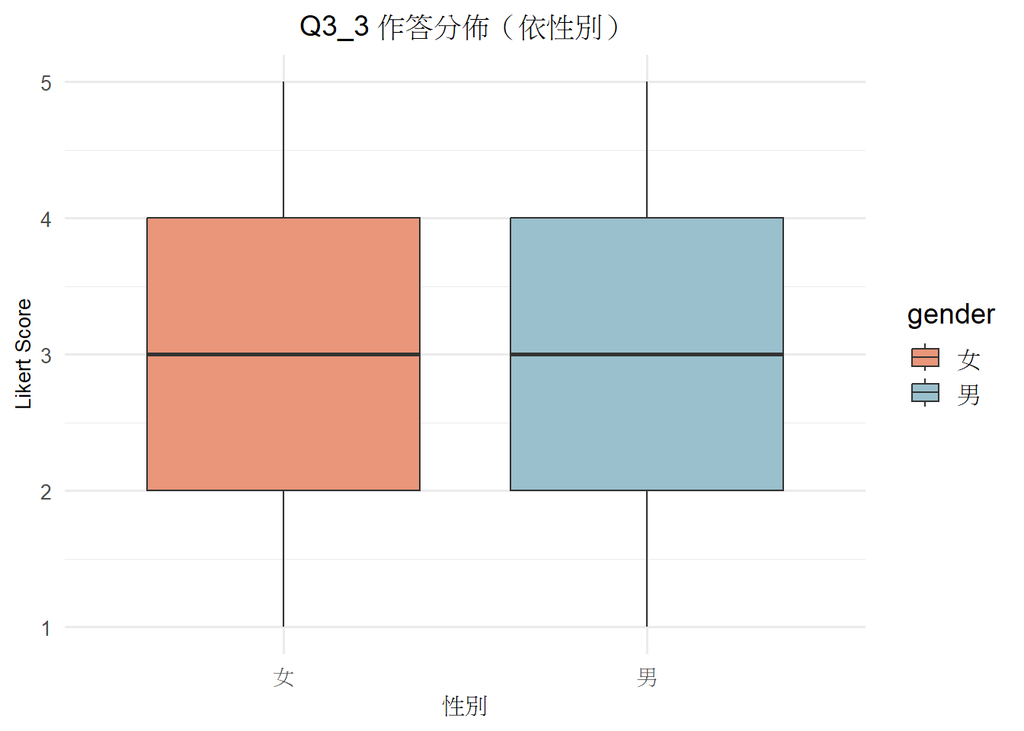

```
## # A tibble: 2 × 9
##   gender  mean variance    sd   min    Q1    Q2    Q3   max
##   <chr>  <dbl>    <dbl> <dbl> <dbl> <dbl> <dbl> <dbl> <dbl>
## 1 女      2.97     1.3   1.14     1     2     3     4     5
## 2 男      2.91     1.38  1.17     1     2     3     4     5
```

平均分數上，女生為 2.97，男生為 2.91，顯示男女學生對於自身衝動消費行為的認知趨於一致，態度皆偏向中立或略微否認。

```r
#t-test Q3_3 gender

Q3_3_data <- df_long %>%
  filter(question == "Q3_3")
table(Q3_3_data$gender)
```

```
##
##  女  男
## 102  55
```

```r
t.test(response ~ gender, data = Q3_3_data, var.equal = FALSE)
```

```
##
##  Welch Two Sample t-test
##
## data:  response by gender
## t = 0.31628, df = 107.75, p-value = 0.7524
## alternative hypothesis: true difference in means between group 女 and group 男 is not equal to 0
## 95 percent confidence interval:
##  -0.3239264  0.4469210
## sample estimates:
## mean in group 女 mean in group 男
##         2.970588         2.909091
```

根據 Welch’s t 檢定結果（t = 0.316，df = 107.75，p = 0.7524），在統計上性別與衝動性消費之間無顯著關聯。

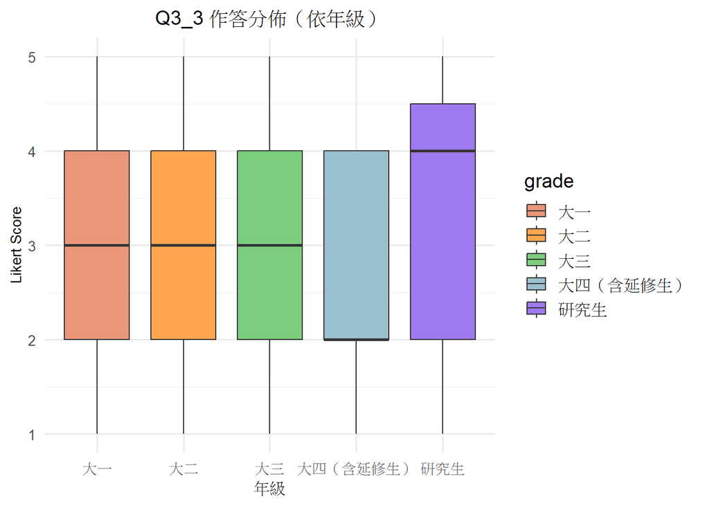

```
## # A tibble: 5 × 9
##   grade             mean variance    sd   min    Q1    Q2    Q3   max
##   <chr>            <dbl>    <dbl> <dbl> <dbl> <dbl> <dbl> <dbl> <dbl>
## 1 大一              2.88     1.44  1.2      1     2     3   4       5
## 2 大三              2.85     1.19  1.09     1     2     3   4       5
## 3 大二              3.37     1.36  1.17     1     2     3   4       5
## 4 大四（含延修生）  2.62     0.96  0.98     1     2     2   4       4
## 5 研究生            3.29     2.57  1.6      1     2     4   4.5     5
```

大二（3.37）與研究生（3.29）的平均分數相對較高，顯示可能因生活壓力降低或收入增加，衝動消費傾向較明顯；大四學生（2.62）則相對保守，可能與即將畢業、開始規劃職涯與經濟有關。

```r
#ANOVA Q3_3 grade

anova_result <- aov(response ~ grade, data = Q3_3_data)
summary(anova_result)
```

```
##              Df Sum Sq Mean Sq F value Pr(>F)
## grade         4  10.85   2.713   2.118 0.0813 .
## Residuals   152 194.74   1.281
## ---
## Signif. codes:  0 '***' 0.001 '**' 0.01 '*' 0.05 '.' 0.1 ' ' 1
```

根據 ANOVA 分析的結果為 F = 2.118，p = 0.0813，雖未達顯著水準，但接近統計顯著邊緣，可觀察出某些年級對衝動消費的自我評估存在差異。

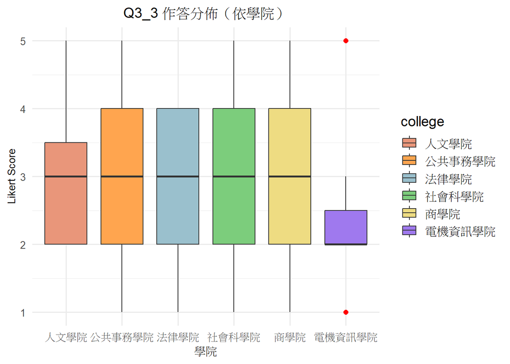

```
## # A tibble: 6 × 9
##   college       mean variance    sd   min    Q1    Q2    Q3   max
##   <chr>        <dbl>    <dbl> <dbl> <dbl> <dbl> <dbl> <dbl> <dbl>
## 1 人文學院      3        1.33  1.15     2     2     3   3.5     5
## 2 公共事務學院  3        1.31  1.14     1     2     3   4       5
## 3 商學院        2.91     1.43  1.2      1     2     3   4       5
## 4 法律學院      2.9      0.94  0.97     1     2     3   4       4
## 5 社會科學院    3.17     1.36  1.17     1     2     3   4       5
## 6 電機資訊學院  2.43     1.62  1.27     1     2     2   2.5     5
```

在平均數上可見以下趨勢：社會科學院（3.17）與人文、公事學院（3.00）分數較高，可能與對個人情緒與消費行為有較高覺察性有關；電機資訊學院（2.43）平均分數最低，且出現極端低值，顯示該群體多半不認為自己具衝動消費行為。

```r
#ANOVA Q3_3 college

anova_result <- aov(response ~ college, data = Q3_3_data)
summary(anova_result)
```

```
##              Df Sum Sq Mean Sq F value Pr(>F)
## college       5   3.27  0.6533   0.488  0.785
## Residuals   151 202.33  1.3399
```

學院間的 ANOVA 分析結果為 F = 0.488，p = 0.785，顯示學院背景與衝動消費傾向之間無顯著差異。

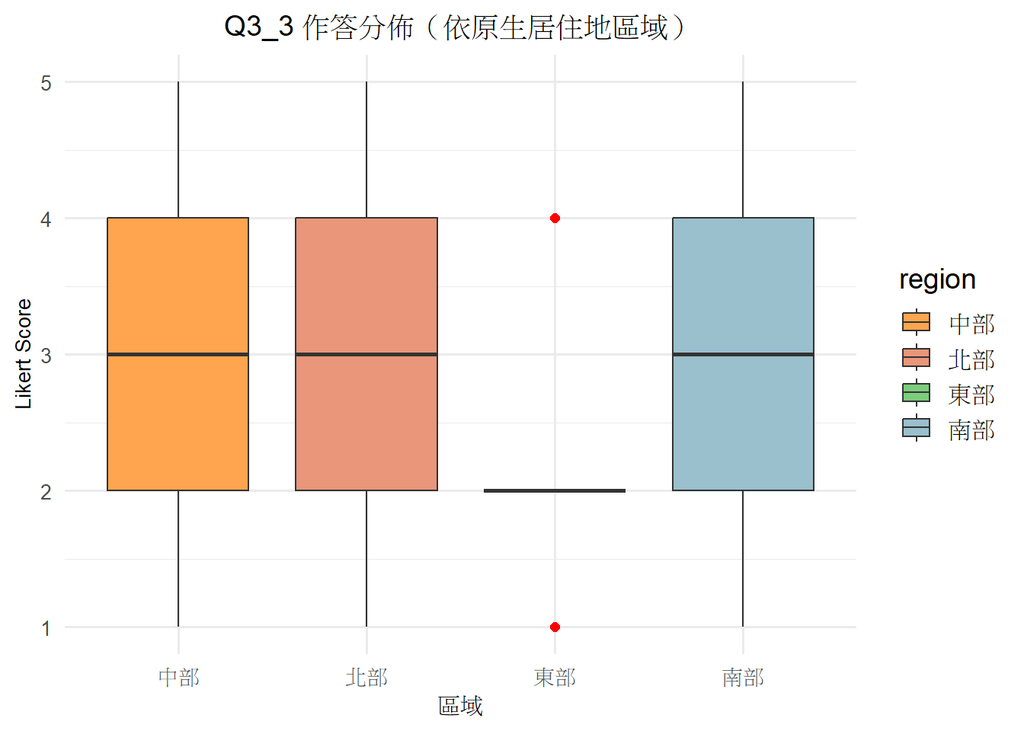

圖表顯示不同原生居住地區學生在該題選項的回答分布情形，北部、中部及南部在中位數上皆為 3 分，表示整體對衝動性消費的自評傾向中性。北部、中部及南部的分布範圍類似，皆涵蓋 Likert 尺度的 2 至 4 分。而東部出現少數離群值（1 分與 4 分），顯示在該區域內部存在個別極端看法。整體而言，不同地區學生在衝動性消費上的回答趨勢相近，無明顯差異。

```
## # A tibble: 4 × 9
##   region  mean variance    sd   min    Q1    Q2    Q3   max
##   <chr>  <dbl>    <dbl> <dbl> <dbl> <dbl> <dbl> <dbl> <dbl>
## 1 中部    2.96     1.19  1.09     1     2     3     4     5
## 2 北部    2.99     1.3   1.14     1     2     3     4     5
## 3 南部    2.92     1.59  1.26     1     2     3     4     5
## 4 東部    2.2      1.2   1.1      1     2     2     2     4
```

```r
#ANOVA Q3_3 region

anova_result <- aov(response ~ region, data = Q3_3_data)
summary(anova_result)
```

```
##              Df Sum Sq Mean Sq F value Pr(>F)
## region        3   2.99  0.9978   0.754  0.522
## Residuals   153 202.60  1.3242
```

ANOVA 檢定結果為 F = 0.754，p = 0.522，表示原生居住地區與衝動性消費之間無顯著關聯。

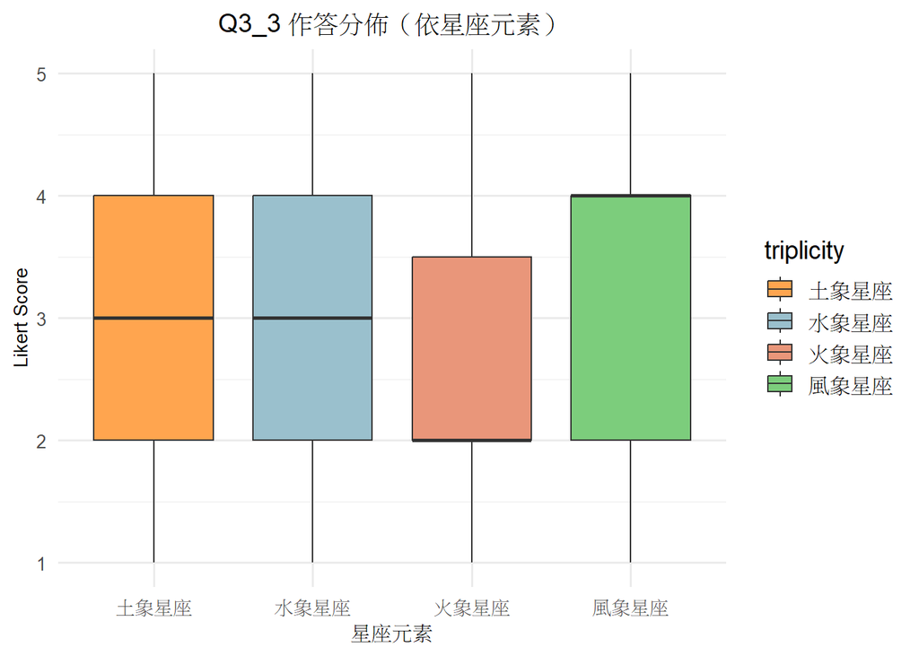

```
## # A tibble: 4 × 9
##   triplicity  mean variance    sd   min    Q1    Q2    Q3   max
##   <chr>      <dbl>    <dbl> <dbl> <dbl> <dbl> <dbl> <dbl> <dbl>
## 1 土象星座    2.95     1.12  1.06     1     2     3   4       5
## 2 水象星座    2.94     1.67  1.29     1     2     3   4       5
## 3 火象星座    2.61     1.25  1.12     1     2     2   3.5     5
## 4 風象星座    3.24     1.08  1.04     1     2     4   4       5
```

觀察數據可發現以下趨勢：風象星座（3.24）與土象（2.95）、水象（2.94）整體較高，顯示在個人表達與變化偏好上可能影響消費模式；火象星座（2.61）反而平均最低，與普遍印象中火象較衝動的刻板印象略有差距，可能因樣本數不足或個體差異造成。

```r
#ANOVA Q3_3 triplicity

anova_result <- aov(response ~ triplicity, data = Q3_3_data)
summary(anova_result)
```

```
##              Df Sum Sq Mean Sq F value Pr(>F)
## triplicity    3   6.71   2.238   1.722  0.165
## Residuals   153 198.88   1.300
```

根據 ANOVA 的結果，星座元素對該題的作答分數並無顯著影響（F = 1.722，p = 0.165）。雖然在平均數上風象星座略高（3.24），火象星座略低（2.61），但整體差異未達統計顯著水準。因此，可推論不同星座元素之間在衝動性消費傾向上並無顯著差異。

## **Q4_5. 在您的消費決策中，最常影響您購買慾望的媒體或平台是？**

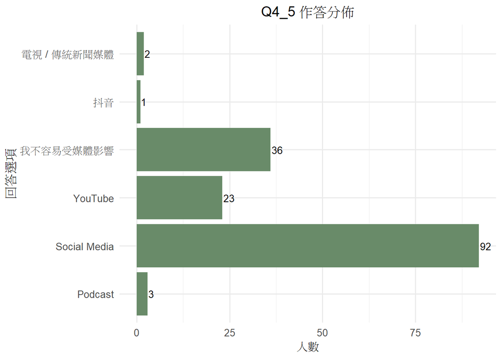

在受訪學生中，社群媒體（Social Media）是最主要影響購買慾望的平台，有 92 人選擇，占多數。其次為「我不容易受媒體影響」（36 人），顯示部分學生對自身購物判斷較有主見。YouTube 影響者亦不少（23 人），而 Podcast、抖音及傳統媒體等影響力則相對有限。整體而言，學生族群的消費慾望主要受到社群平台與影音內容所驅動，反映出新媒體在年輕世代中的高度滲透力。

```r
dfnew$Q4_5_grouped <- dfnew$Q4_5

dfnew$Q4_5_grouped[dfnew$Q4_5 %in% c("Podcast", "電視 / 傳統新聞媒體", "抖音")] <- "其他媒體"

dfnew$Q4_5_grouped <- factor(dfnew$Q4_5_grouped,
                              levels = c("Social Media", "YouTube", "我不容易受媒體影響", "其他媒體"))

table(dfnew$Q4_5_grouped)
```

```
##
##       Social Media            YouTube 我不容易受媒體影響           其他媒體
##                 92                 23                 36                  6
```

為進行卡方檢定並提升統計分析的穩定性，Q4_5 題項中的部分選項經過合併處理。原始資料中，部分媒體類別（如 Podcast、電視／傳統新聞媒體、抖音）填答人數過少，可能導致卡方檢定中期望值過低，影響檢定結果的準確性。為此，這些低頻類別被合併為「其他媒體」，使各組別樣本數相對均衡。

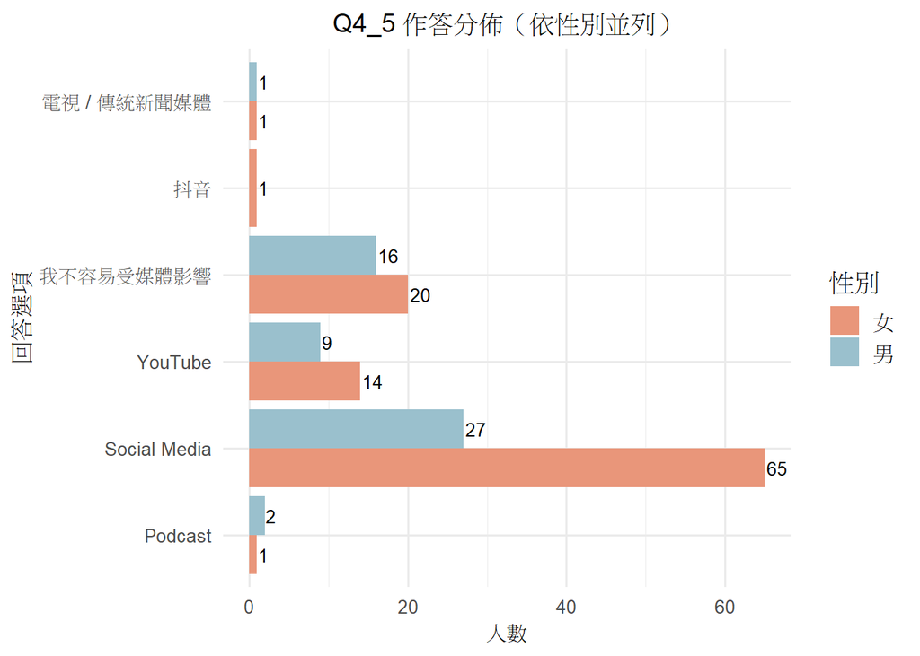

從圖表來看，無論性別為何，「Social Media」皆為最常被認為影響消費決策的媒體來源，尤其女性比例明顯偏高（女性 65 人，男性 27 人）。在其他選項如 YouTube 和「我不容易受媒體影響」的分布上，則呈現男女數量較為接近的狀況；Podcast、抖音與傳統媒體則明顯較少被選擇。

```r
chisq.test(table(dfnew$gender, dfnew$Q4_5_grouped))
```

```
##
##  Pearson's Chi-squared test
##
## data:  table(dfnew$gender, dfnew$Q4_5_grouped)
## X-squared = 3.4678, df = 3, p-value = 0.325
```

由卡方結果顯示，統計量 𝜒<sup>2</sup> 為 3.4678，自由度為 3，對應的 p 值為 0.325，大於常用顯著水準 0.05。由此可知，不同性別在最常受哪種媒體影響方面並無顯著差異，即性別與媒體影響來源之間無統計上的關聯性。

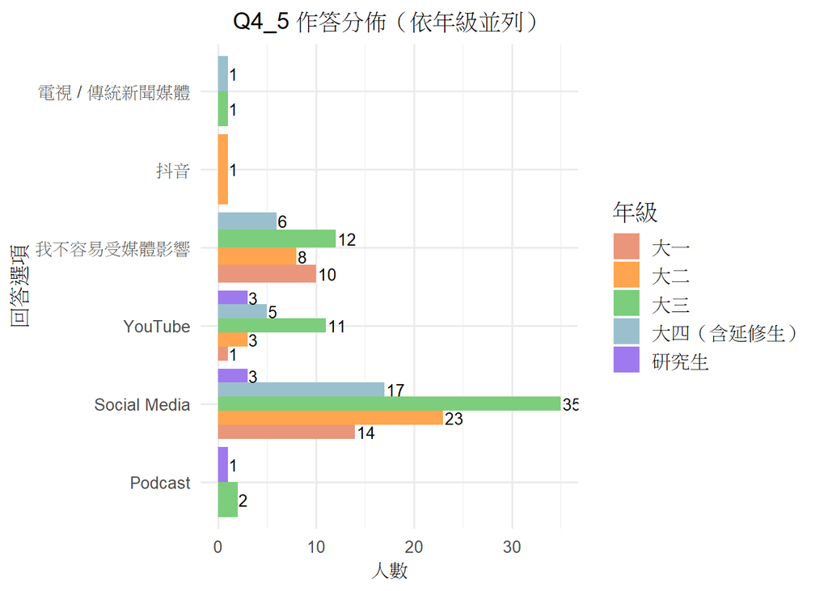

從圖表可觀察到，「Social Media」是各年級學生普遍認為最容易影響其消費慾望的媒體平台，尤其在大三學生中佔比最高（35 人），其餘各年級也都有一定人數選擇該平台。其他媒體如 YouTube 與「我不容易受媒體影響」則在各年級間分布較為平均；而傳統媒體、Podcast 和抖音等選項整體選擇人數偏少。

```r
chisq.test(table(dfnew$grade, dfnew$Q4_5_grouped))
```

```
##
##  Pearson's Chi-squared test
##
## data:  table(dfnew$grade, dfnew$Q4_5_grouped)
## X-squared = 16.249, df = 12, p-value = 0.1801
```

由卡方結果顯示，統計量 𝜒<sup>2</sup> 為 16.249，自由度為 12，p 值為 0.1801，未達常用的顯著水準 0.05。因此推論年級與媒體影響來源之間在統計上並無顯著關聯，亦即不同年級學生在消費時受到的媒體影響來源類型分布無明顯差異。

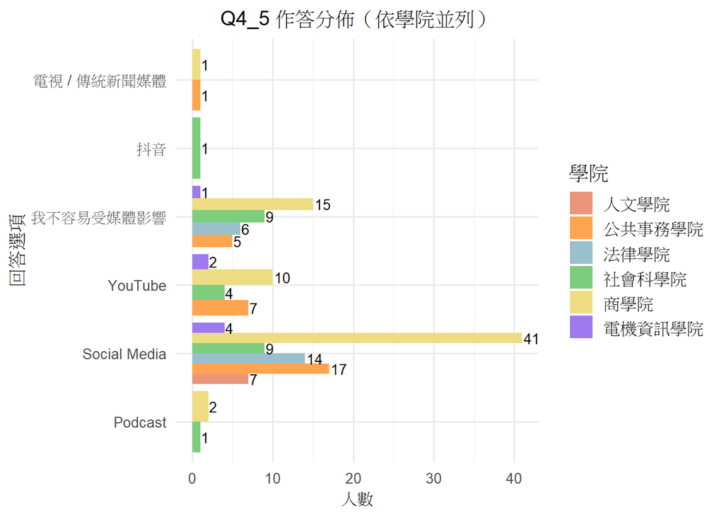

商學院學生在 Social Media 上的影響明顯高於其他學院（41人），同時也在「我不容易受媒體影響」與 YouTube 上占有一席之地。其他學院（如社會科學院、法律學院）在各選項上的分布較平均，選擇「其他媒體」（如 Podcast、電視、抖音）者仍屬少數。

```r
chisq.test(table(dfnew$college, dfnew$Q4_5_grouped))
```

```
##
##  Pearson's Chi-squared test
##
## data:  table(dfnew$college, dfnew$Q4_5_grouped)
## X-squared = 18.531, df = 15, p-value = 0.2358
```

卡方檢定結果顯示不同學院間在媒體影響上的選擇分布亦無顯著差異（𝜒<sup>2</sup> = 18.531, df = 15, p = 0.2358），代表學院背景與媒體影響來源之間無明確關聯。

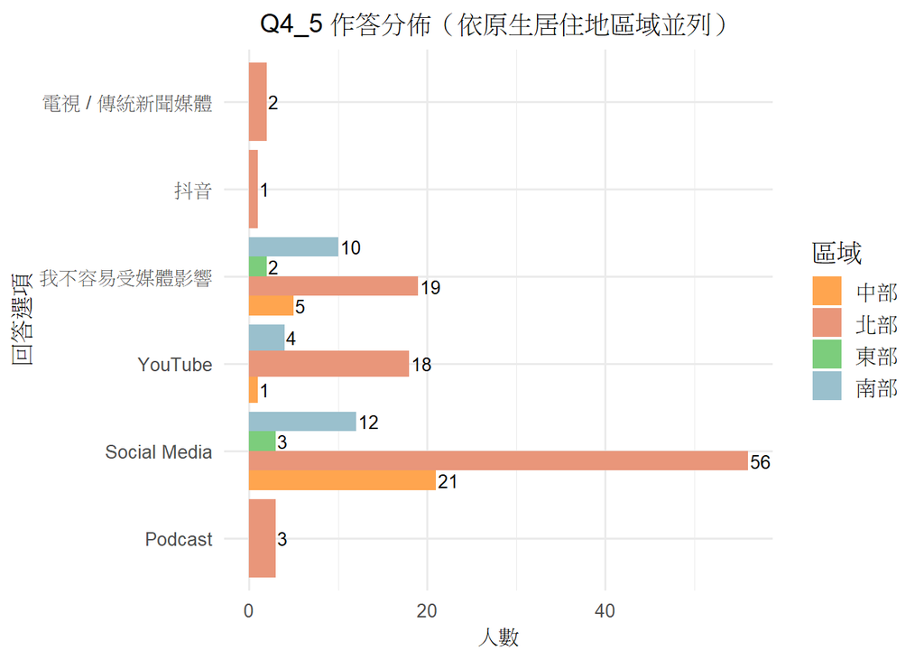

從圖中可以看出，來自北部地區的學生有顯著比例選擇 Social Media（56 人） 為影響其購買慾望的主要平台，其次為 YouTube（18 人）與「我不容易受媒體影響」（19 人），顯示北部學生受到網路社群媒體影響的情形相對明顯。相比之下，其他地區如中部與南部學生則分布相對平均，其中中部地區對 Social Media 的選擇也較高（21 人），但人數低於北部，而南部地區則有相對高比例選擇「我不容易受媒體影響」與 YouTube，顯示其媒體影響來源較多元。東部地區樣本數較少，但大致分布在 Social Media 與「不易受媒體影響」兩類。

```r
chisq.test(table(dfnew$region, dfnew$Q4_5_grouped))
```

```
##
##  Pearson's Chi-squared test
##
## data:  table(dfnew$region, dfnew$Q4_5_grouped)
## X-squared = 13.965, df = 9, p-value = 0.1236
```

檢定結果顯示卡方值 𝜒<sup>2</sup> 為 13.965，自由度為 9，對應的 p 值為 0.1236，高於常見顯著水準 0.05，表示不同原生地區與受影響的媒體平台之間無顯著關聯。雖然圖形上北部學生偏好 Social Media 較為明顯，但整體而言，地區與媒體影響來源之間的關係在統計上並不顯著。

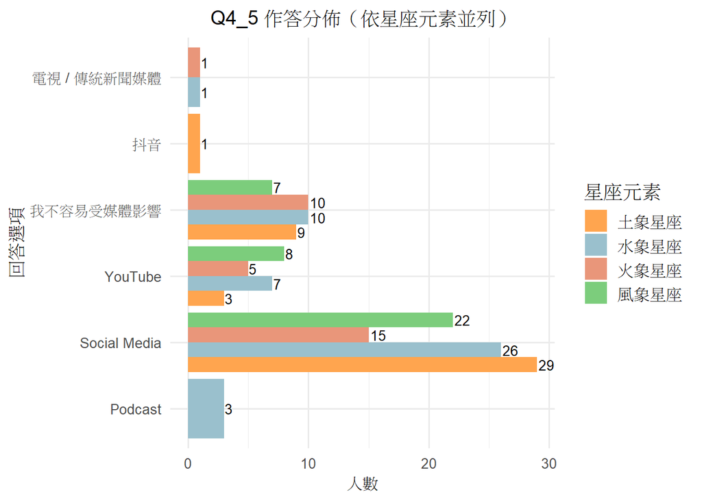

四大星座元素中，土象星座（29人）與水象星座（26人）最多受社群媒體（Social Media）影響，其次為風象星座（22人），而火象星座也以15人表達受其影響。YouTube 在風象星座中略多，其餘選項如「我不容易受媒體影響」則在各類型星座中皆有分布但不突出。整體而言，各星座在媒體影響來源上的差異並不明顯。

```r
chisq.test(table(dfnew$triplicity, dfnew$Q4_5_grouped))
```

```
##
##  Pearson's Chi-squared test
##
## data:  table(dfnew$triplicity, dfnew$Q4_5_grouped)
## X-squared = 10.225, df = 9, p-value = 0.3326
```

由卡方獨立性檢定顯示，星座元素與最常影響購買慾望的媒體平台之間的關聯不顯著（𝜒<sup>2</sup> = 10.225，df = 9，p = 0.3326）。表示在統計上沒有足夠證據顯示兩者之間存在關聯，各星座傾向受到的媒體類型沒有明顯不同。

## **Q4_7. 關稅政策導致非必要性商品（如 3C、服飾等）變貴時，我會調整自己的消費行為**

```r
# q4_7 original

summary(dfnew[,12])
```

```
##       Q4_7
##  Min.   :1.00
##  1st Qu.:3.00
##  Median :4.00
##  Mean   :3.72
##  3rd Qu.:4.00
##  Max.   :5.00
```

```r
#variance
diagonal_variance <- diag(var(dfnew[,12]))
diagonal_variance
```

```
##      Q4_7
## 0.9978769
```

```r
#standard deviation
sqrt(diagonal_variance)
```

```
##      Q4_7
## 0.9989379
```

大多數受訪者對於「當關稅導致非必要性商品（如 3C、服飾）變貴時會調整消費行為」表示認同，整體平均分數為 3.72，且中位數為 4，反映出受訪者普遍具備價格敏感度，會因應價格上漲而改變消費習慣。分數分布主要集中在中高區間，顯示意見趨於一致，較少出現極端反應。

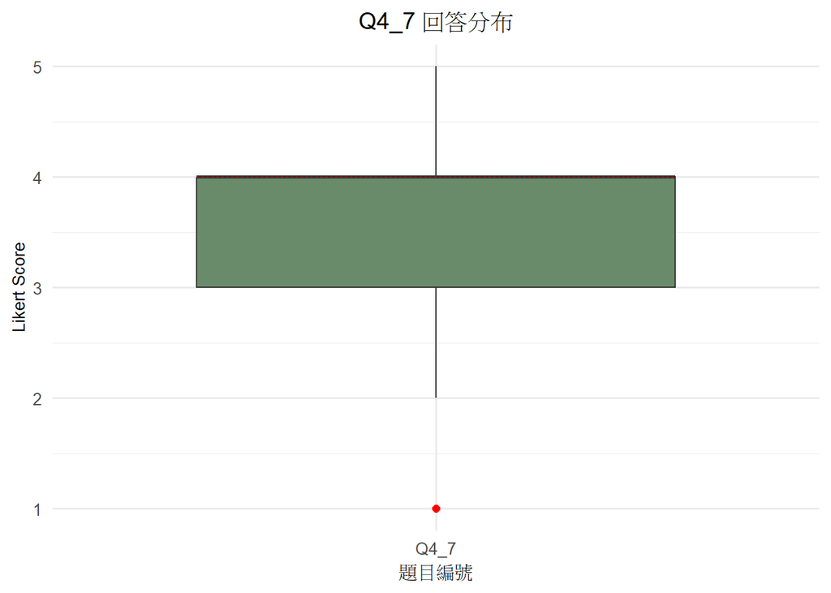

從盒鬚圖可看到，中位數位於4，且大部分數據落於3~4之間，顯示大部分的學生認為關稅政策會影響到他們對於非必需品的需求

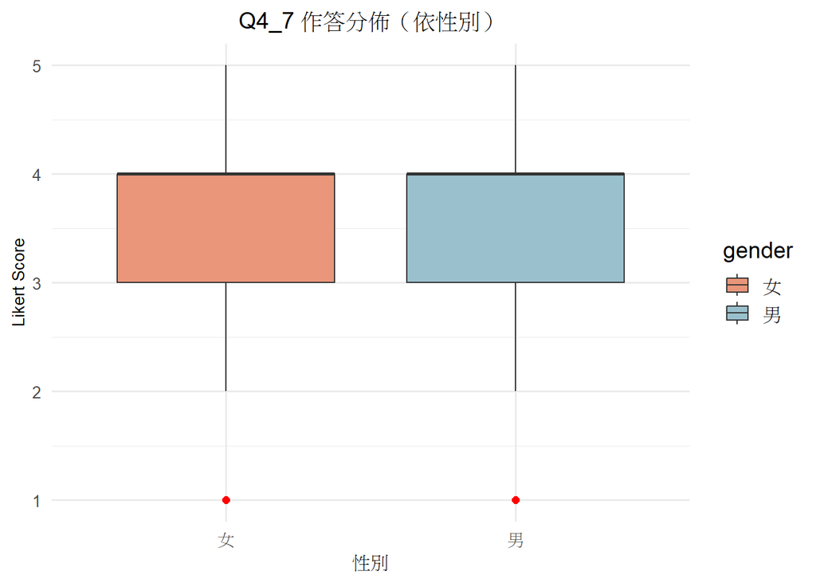

男女不論是中位數或分布幾乎相同，大部分都落在3 ~ 4之間，同時中位數也都位於 4。

```
## # A tibble: 2 × 9
##   gender  mean variance    sd   min    Q1    Q2    Q3   max
##   <chr>  <dbl>    <dbl> <dbl> <dbl> <dbl> <dbl> <dbl> <dbl>
## 1 女      3.82     0.86  0.93     1     3     4     4     5
## 2 男      3.53     1.22  1.1      1     3     4     4     5
```

```r
#t-test Q4_7 gender

Q4_7_data <- df_long %>%
  filter(question == "Q4_7")
table(Q4_7_data$gender)
```

```
##
##  女  男
## 102  55
```